# [Заметки по R](http://bdemeshev.github.io/r_cycle/): Метод главных компонент

16.04.2016

Метод главных компонент позволяет заменить несколько исходных переменных на меньшее количество новых переменных. Новые искусственные переменные называются главными компонентами.

Существует два эквивалентных взгляда на метод главных компонент.

1. Последовательная максимизация выборочного разброса новых переменных:
- Новые переменные являются линейными комбинациями старых
- Новые переменные ортогональны
- Первая главная компонента имеет максимальную выборочную дисперсию
- Вторая главная компонента имеет максимальную выборочную дисперсию при фиксированной первой
- Третья главная компонента имеет максимальную выборочную дисперсию при фиксированной первой и второй
- и т.д.
2. Последовательная минимизация суммы квадратов расстояний от старых точек до новых точек:
- Расположим новые точки на прямой так, чтобы сумма квадратов расстояний до старых была минимальна
- Расположим новые точки на плоскости так, чтобы сумма квадратов расстояний до старых была минимальна
- Расположим новые точки в трехмерном подпространстве так, чтобы сумма квадратов расстояний до старых была минимальна
- и т.д.
- Зададим систему координат, так чтобы они были ортогональны и первая совпадала с прямой, первые две — с плоскостью, первые три с найденным трёхмерным подространством и т.д.

Формально:

Мы хотим вместо $k$ переменных оставить $p<k$. Другими словами, хотим заменить матрицу $X_{n\times k}$ на матрицу $\hat{X}_{n\times k}$ ранга $p$, так чтобы минимизировать сумму квадратов ошибок: $\min \sum_{j=1}^k \sum_{i=1}^n (x_{ij}-\hat{x}_{ij})^2$

### Частный случай: от двух переменных к одной

Что делает регрессия $y$ на $x$? Строит прямую так, чтобы сумма квадратов вертикальных отклонений точек от прямой была бы минимальна.

Что делает регрессия $x$ на $y$? Строит прямую так, чтобы сумма квадратов горизонтальных отклонений точек от прямой была бы минимальна.

Что делает выделение главной компоненты пары векторов $x$ и $y$? Строит прямую так, чтобы сумма квадратов отклонений точек от прямой по перпендикуляру была бы минимальна. И от двух координат на плоскости переходим к одной координате на прямой.

> Шампур — это первая главная компонента шашлыка!

### В R всё просто и быстро:

Загружаем нужные пакеты:

```r
library("knitr")
# opts_chunk$set(cache=TRUE) # кэшируем фрагменты кода

library("ggplot2") # для построения графиков
library("HSAUR") # нам нужен только набор данных по многоборью
# install.packages("HSAUR") # может быть нужно установить пакеты...

opts_chunk$set(fig.align = 'center')
options(width = 110)
theme_set(theme_bw())
```

Загружаем интересующий нас набор данных по многоборью:

```r
data(heptathlon)
head(heptathlon)
```

```
##                     hurdles highjump  shot run200m longjump javelin run800m score
## Joyner-Kersee (USA)   12.69     1.86 15.80   22.56     7.27   45.66  128.51  7291
## John (GDR)            12.85     1.80 16.23   23.65     6.71   42.56  126.12  6897
## Behmer (GDR)          13.20     1.83 14.20   23.10     6.68   44.54  124.20  6858
## Sablovskaite (URS)    13.61     1.80 15.23   23.92     6.25   42.78  132.24  6540
## Choubenkova (URS)     13.51     1.74 14.76   23.93     6.32   47.46  127.90  6540
## Schulz (GDR)          13.75     1.83 13.50   24.65     6.33   42.82  125.79  6411
```

Корреляции исходных переменных:

```r
print(cor(heptathlon), digits = 2)
```

```
##          hurdles highjump  shot run200m longjump javelin run800m score
## hurdles   1.0000  -0.8114 -0.65    0.77   -0.912 -0.0078    0.78 -0.92
## highjump -0.8114   1.0000  0.44   -0.49    0.782  0.0022   -0.59  0.77
## shot     -0.6513   0.4408  1.00   -0.68    0.743  0.2690   -0.42  0.80
## run200m   0.7737  -0.4877 -0.68    1.00   -0.817 -0.3330    0.62 -0.86
## longjump -0.9121   0.7824  0.74   -0.82    1.000  0.0671   -0.70  0.95
## javelin  -0.0078   0.0022  0.27   -0.33    0.067  1.0000    0.02  0.25
## run800m   0.7793  -0.5912 -0.42    0.62   -0.700  0.0200    1.00 -0.77
## score    -0.9232   0.7674  0.80   -0.86    0.950  0.2531   -0.77  1.00
```

Восьмой столбец, `score`, нам не нужен, т.к. это не результат соревнования, а итоговый балл по многоборью. Применяем метод главных компонент к стандартизированным переменным. Стандартизация здесь нужна, так как разные переменные измерены в несопоставимых единицах измерения:

```r
h <- heptathlon[, -8]
hept_pca <- prcomp(h, scale = TRUE)
```

Теперь можно раздобыть сами главные компоненты:

```r
pc <- hept_pca$x
head(pc)
```

```
##                           PC1         PC2        PC3         PC4        PC5         PC6        PC7
## Joyner-Kersee (USA) -4.121448 -1.24240435 -0.3699131 -0.02300174  0.4260062 -0.33932922  0.3479213
## John (GDR)          -2.882186 -0.52372600 -0.8974147  0.47545176 -0.7030659  0.23808730  0.1440158
## Behmer (GDR)        -2.649634 -0.67876243  0.4591767  0.67962860  0.1055252 -0.23919071 -0.1296478
## Sablovskaite (URS)  -1.343351 -0.69228324 -0.5952704  0.14067052 -0.4539282  0.09180564 -0.4865780
## Choubenkova (URS)   -1.359026 -1.75316563  0.1507013  0.83595001 -0.6871948  0.12630397  0.2394820
## Schulz (GDR)        -1.043847  0.07940725  0.6745305  0.20557253 -0.7379335 -0.35578939 -0.1034143
```

Веса исходных переменных в главных компонентах:

```r
loadings <- hept_pca$rotation
head(loadings)
```

```
##                 PC1         PC2         PC3         PC4         PC5         PC6        PC7
## hurdles   0.4528710 -0.15792058 -0.04514996  0.02653873 -0.09494792 -0.78334101 -0.3802471
## highjump -0.3771992  0.24807386  0.36777902 -0.67999172 -0.01879888 -0.09939981 -0.4339311
## shot     -0.3630725 -0.28940743 -0.67618919 -0.12431725 -0.51165201  0.05085983 -0.2176249
## run200m   0.4078950  0.26038545  0.08359211 -0.36106580 -0.64983404  0.02495639  0.4533848
## longjump -0.4562318  0.05587394 -0.13931653 -0.11129249  0.18429810 -0.59020972  0.6120639
## javelin  -0.0754090 -0.84169212  0.47156016 -0.12079924 -0.13510669  0.02724076  0.1729467
```

Посмотрим как первая компонента связана с итоговым результатом спортсмена:

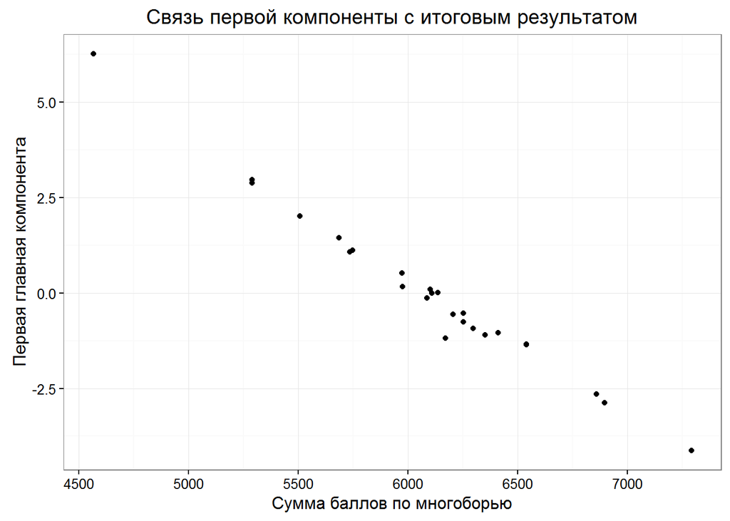

```r
qplot(x = heptathlon$score, y = pc[, 1]) +
  labs(x = "Сумма баллов по многоборью",
       y = "Первая главная компонента",
       title = "Связь первой компоненты с итоговым результатом")
```

```r
cor(heptathlon$score, pc[, 1])
```

```
## [1] -0.9910978
```

Мораль такая: не зная способ подсчета очков за семиборье мы его восстановили! Первая главная компонента вбирает в себя максимум отличий между спортсменами :)